# Three Blocks(B3.1)

Youjin Lee

We are testing independence between network (graph) $G$ and its nodes’ attributes $X$.

$H_{0} : f_{GX} = f_{G} \cdot f_{X}$

$H_{A} : f_{GX} \neq f_{G} \cdot f_{X}$

, where distribution of $G$ and $X$ depends on block membership $Z.$

$Z_{i} = \left\{ \begin{array}{ll} -1 & i \in \mbox{ block 1 } \\ 1 & i \in \mbox{ block 2} \\ 0 & i \in \mbox{ block 3} \end{array} \right.$

Generate a Bernoulli random variable which depends on block membership and a parameter $\omega.$

$X_{i} \overset{i.i.d}{\sim} Bern(0.5 + z_{i} \omega)$

An adjacency matrix of a graph $G \in \mathcal{G}(n ; p,q,r)$ is following:

$Adj_{G} = \left[ \begin{array}{c|c|c} p & q & r \\ \hline q & p & s \\ \hline r & s & p \end{array} \right]$ Generate simple, undirected network $G \sim Adj_{G}.$

Test statistic which is used to measure the distances between two random variables $G \in \mathcal{G}(n; p,q,r,s)$ and $X \in \mathcal{R}$ is defined as follows for all pairs of $\{(k,l); k,l=1,..,n\}$:

$dCorr_{kl}(G,X) = \frac{dCov_{kl}(G,X)}{\sqrt{dVar_{k}(G) \cdot dVar_{l}(X)}}$ ,where

$dCov_{kl}(G,X) = \frac{1}{n^2} \sum\limits_{i,j}^{n} A^{H}_{ij} B^{H}_{ij} I(r(A_{ij}) < k) I(r(B_{ij}) < l )$

$dVar_{k}(G) = \frac{1}{n^2} \sum\limits_{i,j=1}^{n} A^{H}_{ij}A^{H}_{ij} I\big( r(A_{ij}) < k \big)$

$dVar_{k}(X) = \frac{1}{n^2} \sum\limits_{i,j=1}^{n} B^{H}_{ij}B^{H}_{ij} I\big( r(B_{ij}) < k \big)$

where $A^{H} = HAH; A_{ij} = \parallel G_{i} - G_{j} \parallel ; H = I_{n} - J_{n} / n;$ $r(A_{ij}) = k$ if and only if $A_{ij}$ is the $k^{th}$ smallest distance in $\{ A_{ij} ; i,j=1,..,n , i \neq j \}.$

The critical value of the test is based on the prespecified Type-I error $\alpha = 0.05$. P-value for each iteration is obtained through permutation.

The testing power of local distance correlation equals to the best power among all of the local family. What we call global test refers to the test when $k=l=n,$ i.e. a test including all ranges of neighborhood. On the other hand, local optimal is a test of highest power.

- Graph Generation
- Flow Chart
- Power Heatmap
- Euclidean Distance Matrix

## Graph Generation

Set $n=150$ ; $p = 0.30$ ; $q = s = r = 0.00; \omega= 0.15.$

$X_{i} \sim \left\{ \begin{array}{ll} Bern(0.35) & i \in \mbox{ block 1 } \\ Bern(0.65) & i \in \mbox{ block 2} \\ Bern(0.50) & i \in \mbox{ block 3} \end{array} \right.$

$Adj_{G} = \left[ \begin{array}{c|c|c} 0.30 & 0^{*} & 0^{*} \\ \hline 0^{*} & 0.30 & 0^{*} \\ \hline 0^{*} & 0^{*} & 0.30 \end{array} \right]$

To make sure $G$ is connected, $0^{*}$ could be very slightly larger than 0.

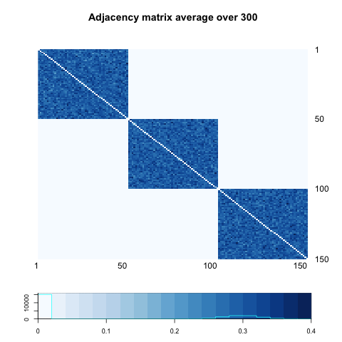

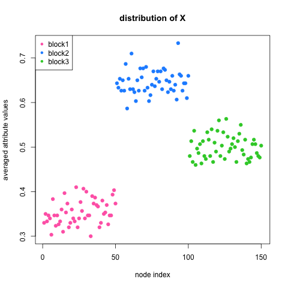

## Flow Chart

### t = 1

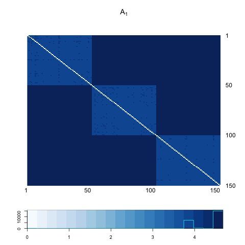

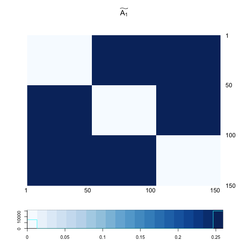

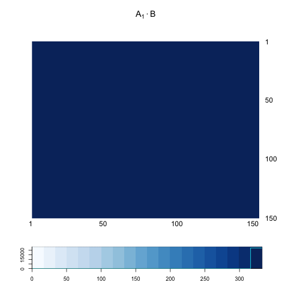

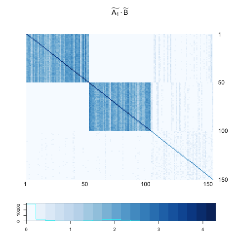

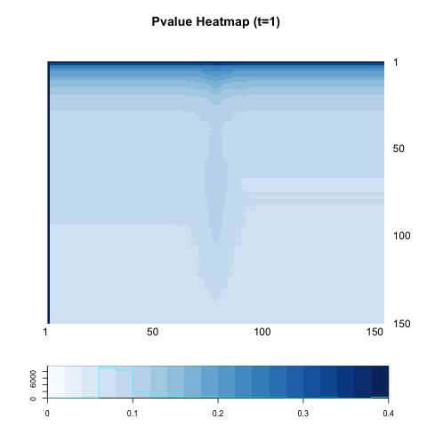

### t = 2

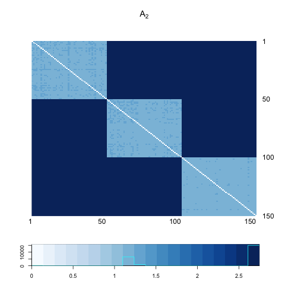

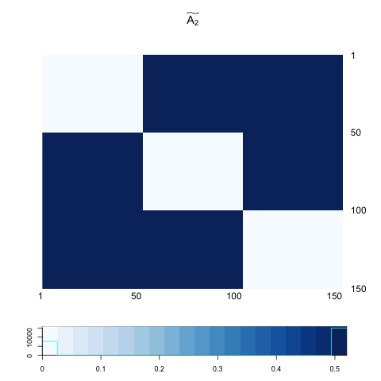

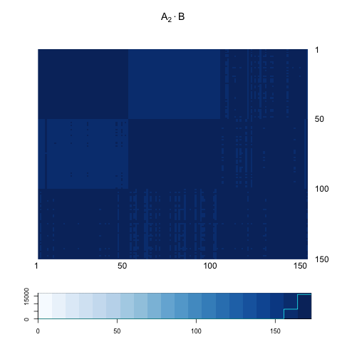

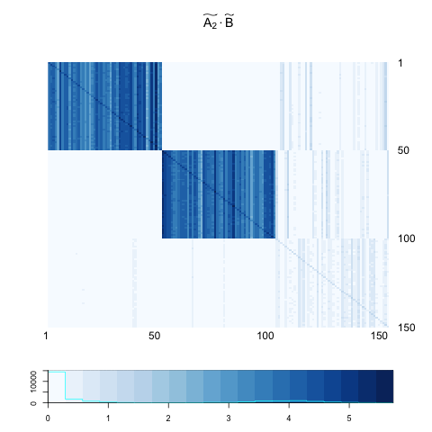

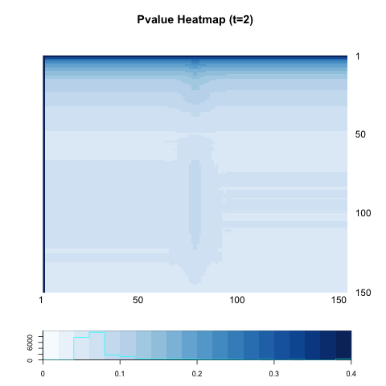

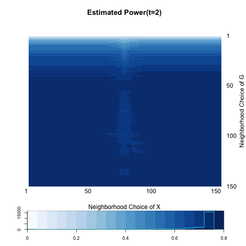

### t = 5

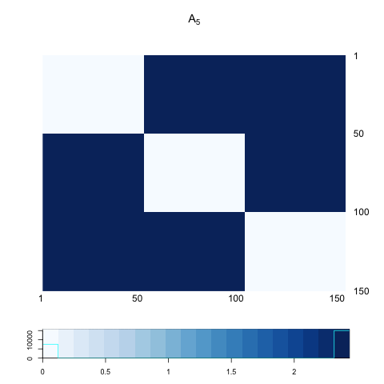

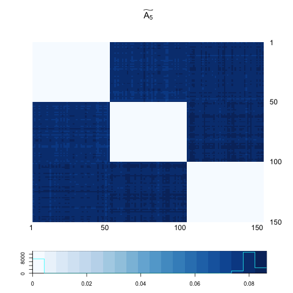

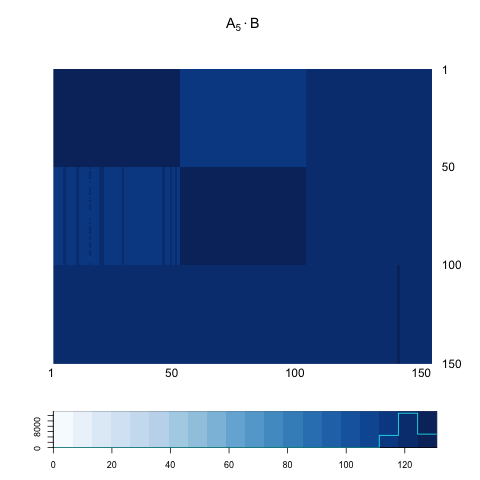

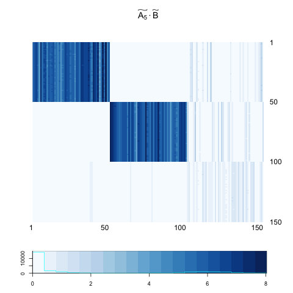

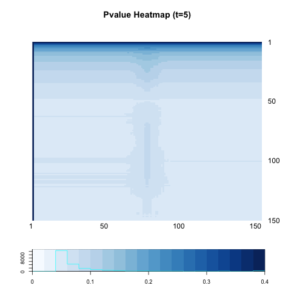

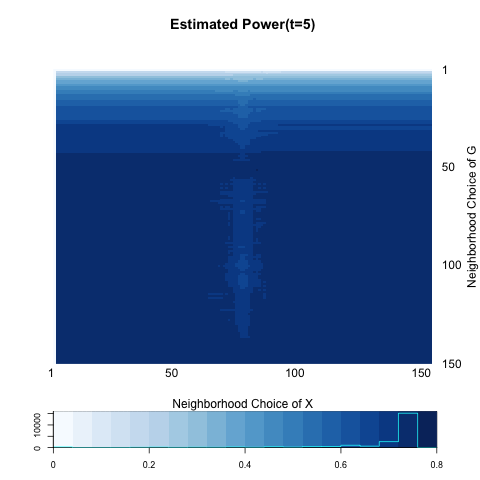

### t = 10

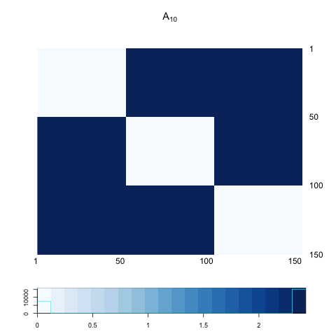

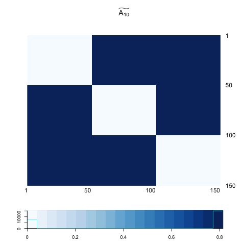

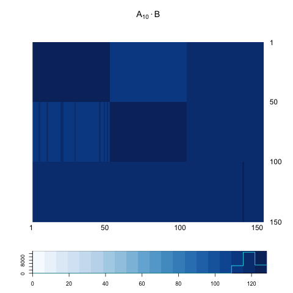

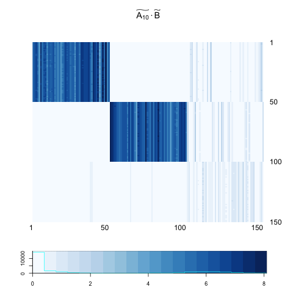

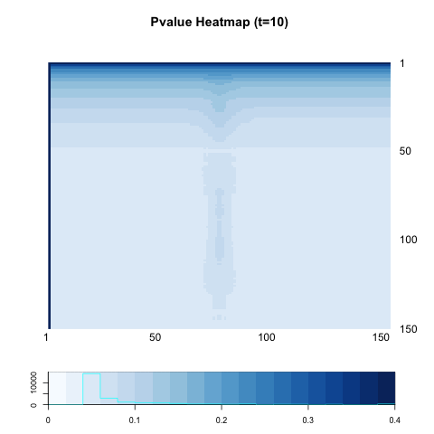

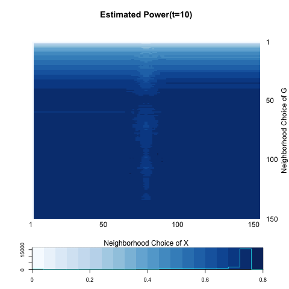

### t = 20

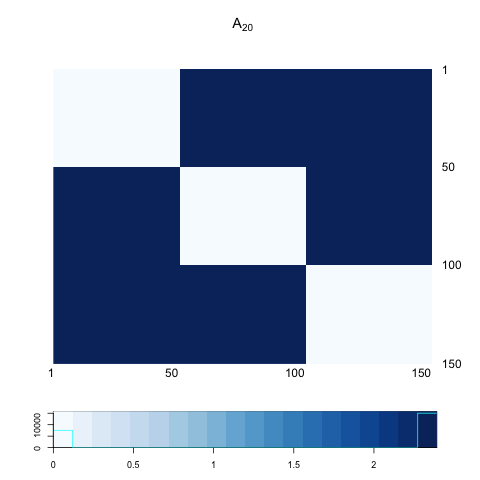

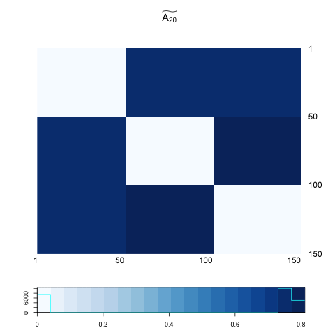

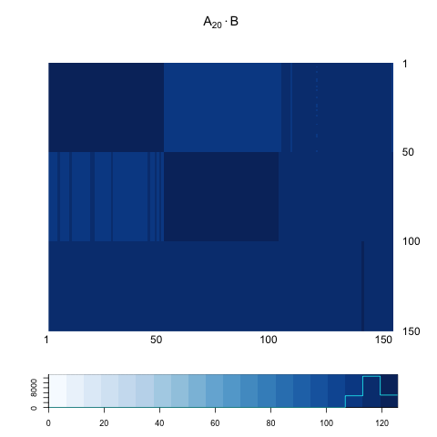

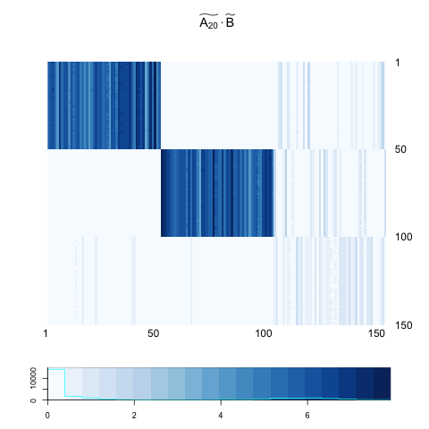

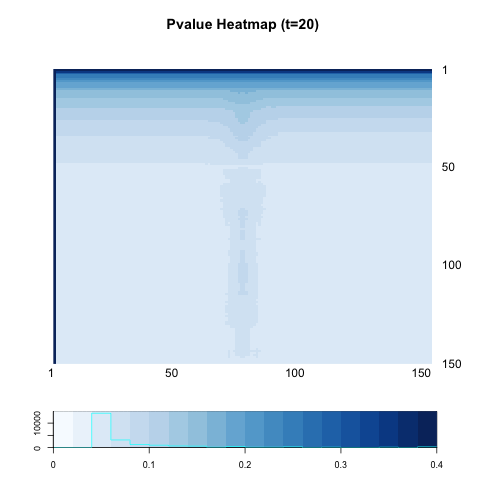

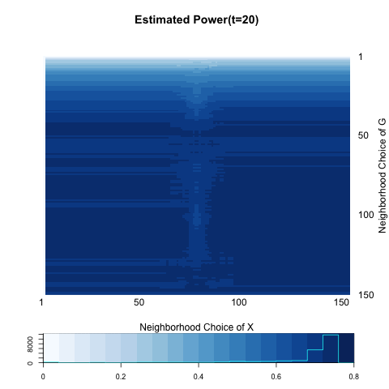